# Expectativa de vida por raça/cor no Brasil entre 2012 e 2022: aplicação do Método Iterativo Intercensal em ambiente R

Marcos R. Gonzaga

Programa de Pós-Graduação em Demografia/UFRN  
marcos.gonzaga@ufrn.br

28-04-2026

### **Introdução**

Este documento descreve a implementação, em ambiente R, do Método Iterativo Intercensal proposto por Merli (1998), fundamentando-se no detalhamento metodológico apresentado por Muniz (2023). O trabalho de Muniz (2023) operacionaliza esse método, o qual reconcilia abordagens baseadas em censos e em métodos de distribuição de mortes (DDM), corrigindo distorções provenientes do sub-registro de óbitos, de erros de cobertura censitária e da migração residual. O autor disponibiliza, originalmente, uma rotina em Stata que automatiza tais técnicas, oferecendo uma solução robusta para que demógrafos e pesquisadores obtenham estimativas de mortalidade e expectativa de vida mais precisas em países em desenvolvimento, prescindindo do uso de tábuas de vida modelo.

O propósito deste documento técnico é fornecer uma função que viabilize a aplicação do Método Iterativo Intercensal para usuários de R. Com isso, busca-se ampliar as possibilidades de emprego desta técnica na construção de tábuas de vida por cor/raça, especialmente em contextos onde a reclassificação racial entre censos demográficos impõe desafios analíticos significativos à pesquisa demográfica.

Primeiramente, apresenta-se uma exposição sucinta dos cálculos inerentes a cada método. Em seguida, descrevem-se as funções desenvolvidas em R para a aplicação de cada técnica, utilizando-se os dados de entrada fornecidos por Muniz (2023). Por fim, apresenta-se uma aplicação dessas funções para a estimação de tábuas de vida por sexo e cor/raça para o Brasil, fundamentada nos dados dos censos demográficos de 2010 e 2022 e nos óbitos registrados ao longo do período intercensitário.

### **1. Método Integrado de Preston (r-method)**

Este método, proposto por Preston (1983) e também denominado *r-method*, oferece uma abordagem alternativa para estimar tábuas de vida fundamentada em duas distribuições etárias censitárias. A técnica vincula-se à família dos métodos de distribuição de óbitos (DDM), guardando estreita relação com o Método das Coortes Sintéticas Extintas (Synthetic Extinct Generations – SEG), proposto por Bennett and Horiuchi (1981), e sendo frequentemente associada aos trabalhos de Preston, Coale, Bennett e Horiuchi.

O r-method requer duas distribuições etárias sucessivas e um conjunto de taxas de crescimento específicas por idade para mensurar as condições de mortalidade. Apresentam-se, a seguir, os cálculos das funções para a obtenção da tábua de vida.

**ALGORITMO 1: cálculo do r-method**

**1.** Taxa média anual de crescimento exponencial por idade por grupo etário $x,x+n\hspace{0.5cm}$ entre os anos $t_1$ e $t_2$:

$$r_x(t_1,t_2)=\frac{log
\left[\frac{N_x(t_2)}{N_x(t_1)}\right]}{t_2-t_1}\hspace{3cm}(1.1)$$

**2.** Acúmulo das taxas de crescimento por idade até o ponto médio do intervalo etário $x,x+n\hspace{0.3cm}$:

$$S_x=\frac{n}{2}r_x+n\sum_{a=0}^{x-5}r_a
\hspace{3cm}(1.2)$$

**3.** Cálculo da média geometrica das populações por grupo etário $x,x+n\hspace{0.5cm}$ entre $t_1$ e $t_2$:

$$N_x^*=\sqrt{N_x(t_1)N_x(t_2)}
\hspace{3cm}(1.3)$$

**4.** Cáculo do número de pessoa-anos vividos entre $x\hspace{0.1cm}$ e $x+n\hspace{0.3cm}$:

$$L_x=N_x^*e^{S_x}
\hspace{3cm}(1.4)$$

**5.** Número de indivíduos sobrevivente à idade $x$:

$$l_x=\frac{L_x+L_{x-5}}{2n}\hspace{1cm}\forall x
> 0 \hspace{3cm}(1.5)$$

**6.** Número de anos-pessoa vividos acima da idade $x$:

$$T_x=\sum_{a\geq x}^{\infty}L_a
\hspace{3cm}(1.6)$$

**7.** Expectativa de vida na idade $x$:

$$e_x=\frac{T_x}{l_x}\hspace{1cm}\forall x
> 0 \hspace{3cm}(1.7)$$

O código abaixo implementa uma função para a aplicação do r-method em R.

**Função implementada para o *r-method*:**

```r
r_method <- function(df, t1, t2, n = 5) {

  #Garantindo que as colunas sejam numéricas (evita erro de leitura):
  df$N_t1 <- as.numeric(df$N_t1)
  df$N_t2 <- as.numeric(df$N_t2)

  # 1.1 Taxa média anual:
  df$r_x <- log(df$N_t2 / df$N_t1) / (t2 - t1)

  # 1.2 Acumulo das taxas de crescimento por idade até o ponto médio do intervalo etário:
  df$S_x <- n * cumsum(ifelse(is.na(df$r_x), 0, df$r_x)) - (n/2) * df$r_x

  # 1.3 Média geométrica:
  df$N_x_star <- sqrt(df$N_t1 * df$N_t2)

  # 1.4 Pessoas-ano vividos:
  df$L_x <- df$N_x_star * exp(df$S_x)

  # 1.5 Sobreviventes na coorte:
  L_x_anterior <- c(NA, df$L_x[-nrow(df)])
  df$l_x <- (df$L_x + L_x_anterior) / (2 * n)

  # 1.6 Pessoas-ano vividos acima da idade x:
  df$T_x <- rev(cumsum(rev(ifelse(is.na(df$L_x), 0, df$L_x))))

  # 1.7 Expectativa de vida na idade x:
  df$e_x <- df$T_x / df$l_x

  return(df)
}
```

Aplica-se a função`r_method` aos dados de entrada fornecidos por Muniz (2023). Esses dados, referentes à população masculina do Vietnã recenseada em 1979 e 1989 e aos óbitos registrados ao longo do período intercensitário, apresentam a seguinte estrutura:

```r
data.viet <- read.csv("C:/Projetos_R/projeto-metodo-iterativo/data/data.csv")
print(data.viet)
```

```
##    age_x    N_t1    N_t2     D
## 1      0 3946224 4710423 48508
## 2      5 3928795 4430179  8029
## 3     10 3632555 3898298  3928
## 4     15 2954333 3427357  3783
## 5     20 2281171 2974282  3856
## 6     25 1742277 2832160  3469
## 7     30 1177320 2361692  3053
## 8     35  966580 1604918  3093
## 9     40  919291 1048246  3345
## 10    45  994602  877589  4836
## 11    50  825356  866821  6215
## 12    55  680996  918363  9138
## 13    60  540920  725079 12070
## 14    65  419164  533445 13645
## 15    70  284003  329167 14310
## 16    75  183222  215510 14357
## 17    80  103773  145637 14787
```

Onde:

- **age_x** = Limite inferior do grupo etário.
- **N_t1** = População do tempo $t_1$.
- **N_t2** = População do tempo $t_2$.
- **D** = Número médio de óbitos entre $t_1$ e $t_2$.

O código abaixo aplica a função `r_method` para estimar a tábua de vida pelo r-method. Nota-se que os resultados apresentados são condizentes com aquele apresentado por Muniz (2023).

```r
r_method_lt <- r_method(data.viet, 1979, 1989, 5)
print(r_method_lt)
```

```
##    age_x    N_t1    N_t2     D          r_x        S_x  N_x_star       L_x
## 1      0 3946224 4710423 48508  0.017701854 0.04425464 4311424.9 4506510.3
## 2      5 3928795 4430179  8029  0.012010723 0.11853608 4171961.8 4696992.7
## 3     10 3632555 3898298  3928  0.007060379 0.16621383 3763081.4 4443542.8
## 4     15 2954333 3427357  3783  0.014851650 0.22099390 3182067.5 3969043.2
## 5     20 2281171 2974282  3856  0.026531376 0.32445147 2604773.7 3603109.6
## 6     25 1742277 2832160  3469  0.048584679 0.51224161 2221352.6 3707500.3
## 7     30 1177320 2361692  3053  0.069613764 0.80773772 1667473.3 3739856.4
## 8     35  966580 1604918  3093  0.050706388 1.10853810 1245504.6 3773786.3
## 9     40  919291 1048246  3345  0.013127085 1.26812178  981653.3 3488963.3
## 10    45  994602  877589  4836 -0.012516428 1.26964842  934265.4 3325611.8
## 11    50  825356  866821  6215  0.004901769 1.25061177  845834.4 2954059.0
## 12    55  680996  918363  9138  0.029903630 1.33762527  790823.3 3013025.1
## 13    60  540920  725079 12070  0.029300922 1.48563665  626266.5 2766705.8
## 14    65  419164  533445 13645  0.024109372 1.61916239  472864.6 2387427.0
```

[output cut: 21 more lines]

### **2. Método de Distribuição dos Óbitos (DDM)**

Este método, proposto por Bennett and Horiuchi (1984), pertence a uma classificação mais ampla, que é a dos Métodos de Distribuição dos Óbitos, como o Growth Balance (Brass 1975), o General Growth Balance de (Hill 1987) e o Synthetic Extinct Generation (Bennett and Horiuchi 1981).

Trata-se de uma técnica de estimação de mortalidade voltada para contextos marcados pelo sub-registro de óbitos e por imprecisões na declaração da idade (Bennett and Horiuchi 1984). O método consiste em derivar o número de mortes da tábua de vida ($d_x$) a partir da média anual de óbitos observados na população ($D_x$) entre dois pontos no tempo ($t_1$ e $t_2$). Para tanto, a distribuição dos óbitos registrados é convertida na distribuição correspondente da tábua de vida por meio das taxas de crescimento específicas por idade do período intercensitário. O pressuposto central dessa abordagem é que a magnitude do sub-registro de óbitos permanece constante em todas as faixas etárias. Apresentam-se, a seguir, os cálculos das funções para a obtenção da tábua de vida Método de Distribuição dos Óbitos proposto por Bennett and Horiuchi (1984).

**ALGORITMO 2: cálculos do Método de Distribuição dos Óbitos**

**1.** O número de óbitos entre as idades $x$ e $x+n\hspace{0.2cm}$ na tábua de vida é uma função do número de óbitos registrados e da acumulação das taxas de crescimento específicas por idade:

$$d_x=D_xexp\left[\frac{n}{2}\left(\sum_{a=0}^{x}r_a+\sum_{a=5}^{x-5}r_a\right)\right]
\hspace{3cm}(2.1)$$

Na equação $(2.1)$ assume-se que $d_0=D_0 \hspace{0.5cm}$ e $d_5=D_5exp\left[(n/2)(r_0+r_5)\right]\hspace{1cm}$.

**2.** O número de anos-pessoa vividos pela coorte entre as idades $x$ e $x+n\hspace{0.5cm}$ é dado por:

$$L_x=nl_{x+n}+\frac{n}{2}d_x\hspace{1cm}
\forall \hspace{0.5cm} x > 0 \hspace{0.5cm} and \hspace{0.5cm} x
\leqslant 75\hspace{3cm}(2.2)$$
Para o primeiro grupo etário considere $L_0=nl_5+0.78d_0 \hspace{0.5cm}$. Já para o último grupo etário faça $L_{80+}=l_{80}log_{10}(l_{80}) \hspace{0.5cm}$.

**3.** A probabilidade de morte entre as idades $x$ e $x+n\hspace{0.3cm}$ é igual à razão entre o número de óbitos entre $x$ e $x+n\hspace{0.3cm}$ e os sobreviventes à idade exata $x$:

$$q_x=\frac{d_x}{l_x}=\frac{l_x-l_{x+n}}{l_x}
\hspace{3cm}(2.3)$$

**4.** O número de anos-pessoa vividos acima da idade $x$ é dado por:

$$T_x=\sum_{a\geq x}^{\infty}L_a
\hspace{3cm}(2.4)$$

**5.** Por fim, a expectativa de vida na idade $x$ é:

$$e_x=\frac{T_x}{l_x}\hspace{1cm}\forall x
> 0 \hspace{3cm}(2.5)$$

O código abaixo implementa uma função para a aplicação do Método de Distribuição dos Óbitos, coforme os calculos apresentados no Algoritimo acima.

**Função implementada para o Método de Distribuição dos Óbitos:**

```r
DDM <- function(df, t1, t2, n = 5) {

  # Preparação dos dados:
  df$N_t1 <- as.numeric(df$N_t1)
  df$N_t2 <- as.numeric(df$N_t2)
  df$D <- as.numeric(df$D)

  # Taxa de crescimento (r_x)
  df$r_x <- log(df$N_t2 / df$N_t1) / (t2 - t1)

  # Cálculo de d_x (Equação 2.1):
  r <- df$r_x
  D <- df$D
  dx_vec <- numeric(nrow(df))

  dx_vec[1] <- D[1] # d0 = D0
  if(nrow(df) > 1) {
    dx_vec[2] <- D[2] * exp((n/2) * (r[1] + r[2])) # d5
  }

  if(nrow(df) > 2) {
    for(i in 3:nrow(df)) {
      # Soma de r_a de 0 até x (index 1 até i)
      sum_0_x <- sum(r[1:i])
      # Soma de r_a de 5 até x-5 (index 2 até i-1)
      sum_5_xm5 <- sum(r[2:(i-1)])

      dx_vec[i] <- D[i] * exp((n/2) * (sum_0_x + sum_5_xm5))
    }
  }
  df$d_x <- dx_vec

  # Cálculo de l_x (Sobreviventes)
  # Soma reversa: quem sobrevive à idade x é a soma de todos que morrerão no futuro
  df$l_x <- rev(cumsum(rev(df$d_x)))

  # Cálculo de L_x:
  Lx_vec <- numeric(nrow(df))
  lx <- df$l_x
  dx <- df$d_x

  # L0 (Primeira linha):
  Lx_vec[1] <- n * lx[2] + 0.78 * dx[1]

  # L_last (Última linha - Grupo aberto 80+)
  last <- nrow(df)
  Lx_vec[last] <- lx[last] * log10(lx[last])

  # Lx para 0 < x <= 75 (grupos etários intermediários):
  for(i in 2:(last-1)) {
    Lx_vec[i] <- n * lx[i+1] + (n/2) * dx[i]
  }
  df$L_x <- Lx_vec

  # Probabilidade de morte (q_x)
  df$q_x <- df$d_x / df$l_x

  # Anos vividos acima da idade x:
  df$T_x <- rev(cumsum(rev(df$L_x)))

  # Expectativa de vida na idade x:
  df$e_x <- df$T_x / df$l_x

  return(df)
}
```

Aplica-se a função`DDM` aos dados da população masculina do Vietnã, conforme código abaixo. Assim como nos resultados para o *r-method*, a tábua de vida estimada pelo Método de Distribuição dos Óbitos é condizente com os resultados apresentados por Muniz (2023).

```r
DDM_lt <- DDM(data.viet, 1979, 1989, 5)
print(DDM_lt)
```

```
##    age_x    N_t1    N_t2     D          r_x       d_x       l_x       L_x
## 1      0 3946224 4710423 48508  0.017701854 48508.000 546274.18 2526667.1
## 2      5 3928795 4430179  8029  0.012010723  8648.115 497766.18 2467210.6
## 3     10 3632555 3898298  3928  0.007060379  4437.493 489118.06 2434496.6
## 4     15 2954333 3427357  3783  0.014851650  4514.329 484680.57 2412117.0
## 5     20 2281171 2974282  3856  0.026531376  5102.993 480166.24 2388073.7
## 6     25 1742277 2832160  3469  0.048584679  5539.218 475063.25 2361468.2
## 7     30 1177320 2361692  3053  0.069613764  6550.935 469524.03 2331242.8
## 8     35  966580 1604918  3093  0.050706388  8965.868 462973.09 2292450.8
## 9     40  919291 1048246  3345  0.013127085 11374.043 454007.22 2241601.0
## 10    45  994602  877589  4836 -0.012516428 16469.031 442633.18 2171993.3
## 11    50  825356  866821  6215  0.004901769 20766.121 426164.15 2078905.4
## 12    55  680996  918363  9138  0.029903630 33308.485 405398.03 1943718.9
## 13    60  540920  725079 12070  0.029300922 51014.252 372089.54 1732912.1
## 14    65  419164  533445 13645  0.024109372 65909.389 321075.29 1440603.0
```

[output cut: 21 more lines]

### **3. Método Iterativo Intercensal (MII)**

A metodologia proposta por Merli (1998) constitui uma abordagem robusta para o tratamento de resíduos decorrentes de migração, reclassificação racial e erros de cobertura. O método opera mediante o ajuste da população do segundo censo por meio de projeções sucessivas, fundamentadas nas razões de sobrevivência estimadas via Método de Distribuição de Óbitos (DDM). Esse procedimento iterativo visa mitigar inconsistências na composição demográfica, sejam elas provenientes de imprecisões nos dados ou de fenômenos sociais.

Ao suavizar anomalias causadas por fluxos migratórios não registrados, sub-registro de óbitos ou transições de autodeclaração, o processo permite a estimação de expectativas de vida mais plausíveis. Assim, o Método Iterativo Intercensal (MII) revela-se essencial para refinar indicadores de mortalidade em contextos de alta volatilidade censitária. O Algoritmo a seguir detalha os procedimentos e cálculos por este método.

**ALGORITMO 3: cálculos do Método Iterativo Intercensal**

**1.** Como etapa inicial, projeta-se a população do ano base — $P(t_1)$ — utilizando-se as razões de sobrevivência da tábua de vida obtida pelo Método de Distribuição de Óbitos (DDM). As razões de sobrevivência da tábua de vida ($p_x$) entre as idades $x$ e $x+n$ representam a proporção de indivíduos que sobrevivem ao longo do período intercensitário. Ao adotar intervalos etários de cinco anos, essas razões são calculadas da seguinte forma:

$$p_x=\frac{L_{x+5}}{L_x} \hspace{1cm}
\forall \hspace{0.5cm} x < 0 \hspace{3cm}(3.1)$$

Para a penúltima faixa etária, considerando os dados estão truncados no itervalo etário aberto de 80 anos e mais, a razão de sobrevivência é definida por:

$$p_{75}=\frac{L_{80}}{L_{75}+L_{80}}$$

A multiplicação dessas razões pela população do ano base — $P(t_1)$ — projeta essa população para cinco anos à frente. Subsequentemente, ao aplicar novamente as respectivas razões de sobrevivência sobre essa população projetada, obtém-se a projeção para mais cinco anos, atingindo-se o tempo $t_2$. Esse encadeamento de projeções é operacionalizado da seguinte forma:

$$N_{x+10}(t_2)^{proj}=N_x(t_1)p_xp_{x+5}\hspace{1cm}
para \hspace{0.5cm} x\ge10 \hspace{3cm}(3.2)$$
A Equação $(3.2)$ projeta o contingente populacional do ano base — $P(t_1)$ — do grupo etário idade $x, x+5\hspace{0.2cm}$, dez anos à frente, correspondendo ao grupo etário $x+10, x+15\hspace{0.2cm}$ em no segundo censo.

Para o primeiro grupo etário, Merli (1998) sugere o emprego da seguinte equação:

$$N_0(t_1+5)^{proj}=N_0(t_1)p_0\hspace{0.1cm}exp\left[
-\frac{n}{2}(r_0+r_5)\frac{L_0}{L_5}\right]\hspace{3cm}(3.3)$$
E para o último grupo etário:

$$N_{80+}(t_1+5)^{proj}=N_{75}(t_1)p_{75}+N_{80+}(t_1)p_{75}\hspace{3cm}(3.4)$$

As equações $(3.3)$ e $(3.4)$ devem ser aplicadas novamente sobre as populações projetadas para $t_1+5\hspace{0.5cm}$, visando deslocá-las para $t_1+10\hspace{0.5cm}$ e obtendo-se, assim, a população projetada para $t_2$. Um passo adicional é requerido para estimar a população projetada no último grupo etário em $t_2$. Especificamente, deve-se projetar a população da faixa de 70 a 74 anos — $N_{70}(t_1)$ — para $t_1+5\hspace{0.5cm}$, utilizando o produto $N_{70}(t_1)p_{70}\hspace{0.5cm}$, a fim de compor a projeção do grupo etário aberto ($N_{80+}$), conforme estabelecido na equação $(3.4)$.

A função `MII`, apresentada no código abaixo, segue as especificações das Equações $(3.1)$ a $(3.4)$. No caso dos nascimentos, a Equação $(3.3)$ é aplicada de forma recursiva para estimar o contingente populacional do primeiro grupo etário, o qual não estava presente no censo base ($t_1$). Já para o grupo aberto, a função implementa a Equação $(3.4)$, na qual a população com 80 anos ou mais em $t+5$ é composta pelos sobreviventes da coorte de 75-79 anos e pelos sobreviventes daqueles que já pertenciam ao grupo $80+$ no período anterior.

**Função implementada para o Método Iterativo Intercensal:**

```r
MII <- function(df, t1, t2, n = 5, tol = 1e-6, max_iter = 100) {

  # Preparação inicial
  df_iter <- df
  df_iter$N_t1 <- as.numeric(df_iter$N_t1)
  df_iter$N_t2 <- as.numeric(df_iter$N_t2)

  # Guarda a população observada original para o dataframe de comparação
  N_t2_original <- df_iter$N_t2

  e0_prev <- 0
  num_ages <- nrow(df_iter)

  # Loop Iterativo (Processo de Conciliação)
  for (i in 1:max_iter) {

    # STAGE 1: Gera tábua de vida via DDM (usa N_t2 projetado das iterações anteriores)
    lt_ddm <- DDM(df_iter, t1, t2, n)

    # Critério de convergência (estabilidade de e0)
    if (abs(lt_ddm$e_x[1] - e0_prev) < tol) {
      message(paste("Convergência atingida na iteração:", i))
      break
    }
    e0_prev <- lt_ddm$e_x[1]

    # Parâmetros para projeção
    L <- lt_ddm$L_x
    r <- lt_ddm$r_x
    N_t1 <- df_iter$N_t1

    # STAGE 2: Cálculo das razões de sobrevivência (px)
    p <- numeric(num_ages)
    for(j in 1:(num_ages-2)) {
      p[j] <- L[j+1] / L[j] # p0 até p70
    }
    p[num_ages-1] <- L[num_ages] / (L[num_ages-1] + L[num_ages]) # p75

    # Termo exponencial para correção de N0 (Equação 3.3)
    term_exp <- exp(-(n/2) * (r[1] + r[2]) * (L[1]/L[2]))

    # Projeção t1 -> t1+5
    N_5 <- numeric(num_ages)
    N_5[1] <- N_t1[1] * p[1] * term_exp
    for(j in 1:(num_ages-1)) {
      N_5[j+1] <- N_t1[j] * p[j]
    }
    N_5[num_ages] <- N_5[num_ages] + (N_t1[num_ages] * p[num_ages-1])

    # Projeção t1+5 -> t2 (t1+10)
    N_10 <- numeric(num_ages)
    N_10[1] <- N_5[1] * p[1] * term_exp
    for(j in 1:(num_ages-1)) {
      N_10[j+1] <- N_5[j] * p[j]
    }
    N_10[num_ages] <- N_10[num_ages] + (N_5[num_ages] * p[num_ages-1])

    # STAGE 3 & 4: Atualiza N_t2 com a projeção (o DDM na próxima volta usará estas taxas)
    df_iter$N_t2 <- N_10
  }

  # --- Construção dos Objetos de Retorno ---

  # 1. Tábua DDM final (já calculada no loop)
  tabua_ddm_final <- lt_ddm

  # 2. Tábua CBM final (usando a população projetada que convergiu)
  tabua_r_method_final <- r_method(df_iter, t1, t2, n)

  # 3. Dataframe de comparação das populações
  df_comparacao <- data.frame(
    age_x          = df$age_x,
    N_t2_observada = N_t2_original,
    N_t2_projetada = df_iter$N_t2,
    diferenca      = N_t2_original - df_iter$N_t2,
    razao          = N_t2_original / df_iter$N_t2
  )

  # Retorna a lista com os três objetos
  return(list(
    DDM_Final  = tabua_ddm_final,
    r_method_Final  = tabua_r_method_final,
    Comparacao = df_comparacao
  ))
}

# --- Execução ---
resultados <- MII(data.viet, 1979, 1989, 5)
```

A função `MII` inicia-se com a geração de uma tábua de vida via função `DDM`, fundamentada nas taxas de crescimento populacional $(r_x)$, obtidas pela função `r_method` a partir das populações recenseadas em $N(t_1)$ e $N(t_2)$ (Estágio 1, conforme descrito por Muniz (2023)). A cada iteração, a função projeta $N(t_1)\hspace{0.2cm}$, com base nas razões de sobrevivência das tábuas de vida geradas pela função `DDM`, e substitui o valor observado de $N(t_2)\hspace{0.5cm}$ pelo valor projetado, utilizando-o como entrada para a rodada seguinte do `r_method` (Estágios 2 e 3).

Nesse processo iterativo, novas taxas de crescimento ($r_x$) são calculadas, considerando a diferença entre o censo observado em $t_1$ e a projeção teórica para $t_2$. Esse procedimento “limpa” as taxas de crescimento de “erros” de enumeração diferencial entre os dois levantamentos censitários causados por fluxos migratórios não incorporados ou fenômenos que alteram a composição da população, como a reclassificação racial. No estágio final (Estágio 4), a tábua de vida pelo DDM é atualizada com base nessas novas taxas — agora livres dos “erros”. Essa tábua gera novas razões de sobrevivência, reiniciando o ciclo até que a estabilidade seja alcançada. O processo converge quando a variação na expectativa de vida entre duas iterações torna-se insignificante (inferior a $0,000001\hspace{0.5cm}$). No exemplo em questão, com os dados do Vietnã, foram necessárias 50 iterações para atingir a convergência.

A função `MII` gera os seguintes objetos:

- **DDM_Final:** Tábua de vida obtida via DDM, atualizada pelo método iterativo com taxas de crescimento corrigidas.
- **r_method_Final:** Tábua de vida obtida via *r-method*, atualizada pelo método iterativo com taxas de crescimento corrigidas.
- **comparacao:** *Dataframe* contendo as populações observada e projetada para $t_2$, bem como as diferenças e as razões entre ambas. Essa comparação é fundamental para identificar em quais faixas etárias o censo observado mais se distanciou da dinâmica demográfica esperada. Por exemplo, razões significativamente diferentes de 1 indicam forte presença de fluxos migratórios ou mudanças e composição da população exposta ao risco como, por exemplo, os efeitos causados pela reclassificação racial.

O código abaixo extrai e exibe os resultados pelo Método de Distribuição dos Óbitos e pelo r-method no âmbinte do Método Iterativo. Resultados esses que são coerentes com aqueles apresentados por Muniz (2023).

```r
# 1. Acessar a tábua de vida pelo método DDM (após convergência)
ddm_lt_final <- resultados$DDM_Final
print(ddm_lt_final)
```

```
##    age_x    N_t1      N_t2     D          r_x       d_x       l_x       L_x
## 1      0 3946224 3862406.5 48508 -0.002146873 48508.000 527347.39 2432033.2
## 2      5 3928795 3811545.0  8029 -0.003029814  7925.760 478839.39 2374382.5
## 3     10 3632555 3804736.8  3928  0.004631057  3893.046 470913.63 2344835.5
## 4     15 2954333 3847039.7  3783  0.026403103  4051.812 467020.58 2324973.4
## 5     20 2281171 3566985.7  3856  0.044703200  4933.472 462968.77 2302510.2
## 6     25 1742277 2892220.3  3469  0.050683162  5633.578 458035.30 2276092.6
## 7     30 1177320 2224702.0  3053  0.063638231  6598.264 452401.72 2245513.0
## 8     35  966580 1688998.2  3093  0.055812678  9011.042 445803.46 2206489.7
## 9     40  919291 1129586.6  3345  0.020600431 11796.568 436792.42 2154470.7
## 10    45  994602  911632.2  4836 -0.008710604 17569.325 424995.85 2081055.9
## 11    50  825356  845514.4  6215  0.002413039 22226.569 407426.52 1981566.2
## 12    55  680996  878628.7  9138  0.025480593 35040.280 385199.95 1838399.1
## 13    60  540920  674950.2 12070  0.022136755 52134.302 350159.67 1620462.6
## 14    65  419164  491944.3 13645  0.016010332 64834.700 298025.37 1328040.1
```

[output cut: 21 more lines]

```r
# 2. Acessar a tábua de vida pelo r-method (após convergência)
r_method_lt_final <- resultados$r_method_Final
print(r_method_lt_final)
```

```
##    age_x    N_t1      N_t2     D          r_x          S_x  N_x_star       L_x
## 1      0 3946224 3862406.5 48508 -0.002146873 -0.005367182 3904090.3 3883192.5
## 2      5 3928795 3811545.0  8029 -0.003029814 -0.018308898 3869726.0 3799520.2
## 3     10 3632555 3804736.8  3928  0.004631057 -0.014305789 3717649.2 3664843.9
## 4     15 2954333 3847039.7  3783  0.026403103  0.063279610 3371266.3 3591493.1
## 5     20 2281171 3566985.7  3856  0.044703200  0.241045366 2852526.0 3630064.0
## 6     25 1742277 2892220.3  3469  0.050683162  0.479511269 2244782.6 3625963.2
## 7     30 1177320 2224702.0  3053  0.063638231  0.765314750 1618390.0 3479005.8
## 8     35  966580 1688998.2  3093  0.055812678  1.063942023 1277713.5 3702522.0
## 9     40  919291 1129586.6  3345  0.020600431  1.254974795 1019028.4 3574496.7
## 10    45  994602  911632.2  4836 -0.008710604  1.284699361  952213.8 3440902.2
## 11    50  825356  845514.4  6215  0.002413039  1.268955448  835374.4 2971539.5
## 12    55  680996  878628.7  9138  0.025480593  1.338689527  773526.1 2950261.0
## 13    60  540920  674950.2 12070  0.022136755  1.457732897  604230.2 2595898.7
## 14    65  419164  491944.3 13645  0.016010332  1.553100614  454098.4 2146115.0
```

[output cut: 21 more lines]

```r
# 3. Analisar a comparação entre populações (Observado vs Projetado)
comparacao <- resultados$Comparacao
print(comparacao)
```

```
##    age_x N_t2_observada N_t2_projetada   diferenca     razao
## 1      0        4710423      3862406.5  848016.456 1.2195565
## 2      5        4430179      3811545.0  618633.976 1.1623053
## 3     10        3898298      3804736.8   93561.154 1.0245907
## 4     15        3427357      3847039.7 -419682.660 0.8909076
## 5     20        2974282      3566985.7 -592703.724 0.8338363
## 6     25        2832160      2892220.3  -60060.350 0.9792338
## 7     30        2361692      2224702.0  136989.993 1.0615768
## 8     35        1604918      1688998.2  -84080.198 0.9502189
## 9     40        1048246      1129586.6  -81340.626 0.9279908
## 10    45         877589       911632.2  -34043.196 0.9626569
## 11    50         866821       845514.4   21306.600 1.0251996
## 12    55         918363       878628.7   39734.333 1.0452231
## 13    60         725079       674950.2   50128.777 1.0742703
## 14    65         533445       491944.3   41500.667 1.0843605
## 15    70         329167       327978.2    1188.796 1.0036246
## 16    75         215510       191360.4   24149.588 1.1261995
## 17    80         145637       116601.1   29035.861 1.2490187
```

### **4. Expectativa de vida por sexo e raça no Brasil entre 2010 e 2022**

Os quadros abaixo apresentam o contingente de mulheres por raça/cor no Brasil em 2012 e 2022, cujos dados servem de entrada para as funções `r-method`, `DDM` e `MII`. Seguindo a padronização proposta por Muniz (2023), a estrutura desses dados replica aquela aplicada à população masculina do Vietnã.

Para o ano de 2012, os dados foram obtidos via interpolação linear entre os censos de 2010 e 2022, conforme a metodologia de Gonzaga et al. (2026). As populações por cor/raça em ambos os anos já incorporam os ajustes para diferenciais de cobertura por sexo e grupos etários, em conformidade com as estimativas da Revisão 2024 do IBGE (IBGE 2024). Ressalta-se que, embora as fórmulas e funções permitam adaptações para distintos intervalos intercensitários, optou-se por restringir esta aplicação ao decênio 2012–2022 para fins de estimação das tábuas de vida intercensitárias por sexo e cor/raça no Brasil.

**Mulheres brancas:**

```r
print(df.branca)
```

```
##    age_x    N_t1    N_t2           D
## 1      0 3481124 3092509   627.86777
## 2      5 3337149 2987385    47.46281
## 3     10 3479260 2842712    59.54545
## 4     15 3715497 3017617   117.28099
## 5     20 3844396 3240724   157.33884
## 6     25 4044491 3331945   193.86777
## 7     30 3979166 3420894   270.67769
## 8     35 3544104 3633309   377.30579
## 9     40 3356813 3638847   510.85950
## 10    45 3272085 3216781   713.92562
## 11    50 2947573 3040266  1008.33884
## 12    55 2506014 2955953  1403.09091
## 13    60 2023705 2635511  1839.85124
## 14    65 1547371 2188413  2297.33884
## 15    70 1228746 1719547  2754.91736
## 16    75  961381 1238532  3337.93388
## 17    80 1218578 1608516 12054.42149
```

**Mulheres pardas:**

```r
print(df.parda)
```

```
##    age_x    N_t1    N_t2          D
## 1      0 3212422 3143091  711.03306
## 2      5 3666785 3519453   55.59504
## 3     10 4129143 3623290   73.79339
## 4     15 4100284 3723965  155.99174
## 5     20 3863901 3928115  194.89256
## 6     25 3874210 3960476  229.85950
## 7     30 3719669 3869796  309.05785
## 8     35 3203843 3942886  422.20661
## 9     40 2842516 3752168  544.41322
## 10    45 2579083 3231033  702.64463
## 11    50 2199658 2849574  900.87603
## 12    55 1769910 2544742 1131.85950
## 13    60 1359059 2104406 1349.40496
## 14    65  997175 1613913 1547.94215
## 15    70  739116 1153833 1687.87603
## 16    75  516502  762326 1822.78512
## 17    80  580665  859343 5059.42149
```

**Mulheres pretas:**

```r
print(df.preta)
```

```
##    age_x   N_t1   N_t2           D
## 1      0 349921 424916   41.157025
## 2      5 449559 524509    5.733333
## 3     10 554264 562277    8.619835
## 4     15 640038 706729   21.272727
## 5     20 686136 864165   31.933884
## 6     25 736117 902965   44.181818
## 7     30 718190 873567   64.289256
## 8     35 616925 922729   94.272727
## 9     40 563439 898303  126.123967
## 10    45 526923 779890  168.140496
## 11    50 475299 696061  225.148760
## 12    55 389621 624524  290.330579
## 13    60 306922 539775  349.884298
## 14    65 228387 424424  385.454545
## 15    70 173044 310325  405.016529
## 16    75 125042 204224  416.305785
## 17    80 144278 240500 1140.256198
```

**Método Integrado de Preston (r-method)**

No código a seguir, com base nos dados de entrada previamente organizados, estimam-se as tábuas de vida para a população feminina no Brasil, desagregadas por categoria de cor/raça, utilizando-se a função r_method com os argumentos pertinentes.

**Mulheres Brancas:**

```r
r_method_lt_branca <- r_method(df.branca, 2012, 2022, 5)
print(r_method_lt_branca)
```

```
##    age_x    N_t1    N_t2           D          r_x         S_x N_x_star     L_x
## 1      0 3481124 3092509   627.86777 -0.011837249 -0.02959312  3281068 3185394
## 2      5 3337149 2987385    47.46281 -0.011071843 -0.08686585  3157428 2894730
## 3     10 3479260 2842712    59.54545 -0.020206110 -0.16506074  3144922 2666398
## 4     15 3715497 3017617   117.28099 -0.020804500 -0.26758726  3348425 2562293
## 5     20 3844396 3240724   157.33884 -0.017081974 -0.36230345  3529678 2456907
## 6     25 4044491 3331945   193.86777 -0.019379949 -0.45345826  3670970 2332633
## 7     30 3979166 3420894   270.67769 -0.015117033 -0.53970071  3689486 2150685
## 8     35 3544104 3633309   377.30579  0.002485843 -0.57127869  3588429 2026755
## 9     40 3356813 3638847   510.85950  0.008067486 -0.54489537  3494986 2026751
## 10    45 3272085 3216781   713.92562 -0.001704623 -0.52898821  3244315 1911553
## 11    50 2947573 3040266  1008.33884  0.003096289 -0.52550904  2993561 1769956
## 12    55 2506014 2955953  1403.09091  0.016512766 -0.47648640  2721702 1690072
## 13    60 2023705 2635511  1839.85124  0.026414710 -0.36916771  2309436 1596535
## 14    65 1547371 2188413  2297.33884  0.034661926 -0.21647612  1840187 1481998
```

[output cut: 21 more lines]

**Mulheres pardas:**

```r
r_method_lt_parda <- r_method(df.parda, 2012, 2022, 5)
print(r_method_lt_parda)
```

```
##    age_x    N_t1    N_t2          D          r_x          S_x  N_x_star     L_x
## 1      0 3212422 3143091  711.03306 -0.002181846 -0.005454615 3177567.4 3160282
## 2      5 3666785 3519453   55.59504 -0.004100968 -0.021161649 3592363.8 3517142
## 3     10 4129143 3623290   73.79339 -0.013068743 -0.064085924 3867955.9 3627850
## 4     15 4100284 3723965  155.99174 -0.009626728 -0.120824601 3907597.0 3462871
## 5     20 3863901 3928115  194.89256  0.001648237 -0.140770827 3895875.7 3384302
## 6     25 3874210 3960476  229.85950  0.002202245 -0.131144622 3917105.5 3435658
## 7     30 3719669 3869796  309.05785  0.003956711 -0.115747233 3793990.0 3379308
## 8     35 3203843 3942886  422.20661  0.020756192 -0.053964978 3554207.0 3367488
## 9     40 2842516 3752168  544.41322  0.027764423  0.067336559 3265822.6 3493305
## 10    45 2579083 3231033  702.64463  0.022536799  0.193089614 2886711.3 3501556
## 11    50 2199658 2849574  900.87603  0.025886762  0.314148516 2503615.0 3427682
## 12    55 1769910 2544742 1131.85950  0.036310057  0.469640563 2122254.5 3394375
## 13    60 1359059 2104406 1349.40496  0.043724069  0.669725879 1691157.0 3304016
## 14    65  997175 1613913 1547.94215  0.048149066  0.899408718 1268603.0 3118416
```

[output cut: 21 more lines]

**Mulheres pretas:**

```r
r_method_lt_preta <- r_method(df.preta, 2012, 2022, 5)
print(r_method_lt_preta)
```

```
##    age_x   N_t1   N_t2           D         r_x        S_x N_x_star       L_x
## 1      0 349921 424916   41.157025 0.019418409 0.04854602 385599.6  404780.7
## 2      5 449559 524509    5.733333 0.015419548 0.13564091 485590.1  556132.0
## 3     10 554264 562277    8.619835 0.001435350 0.17777816 558256.1  666870.6
## 4     15 640038 706729   21.272727 0.009911973 0.20614647 672557.4  826528.1
## 5     20 686136 864165   31.933884 0.023068786 0.28859837 770022.5 1027637.9
## 6     25 736117 902965   44.181818 0.020429472 0.39734402 815283.9 1213034.6
## 7     30 718190 873567   64.289256 0.019585067 0.49738036 792077.7 1302498.8
## 8     35 616925 922729   94.272727 0.040258812 0.64699006 754489.6 1440912.1
## 9     40 563439 898303  126.123967 0.046644835 0.86424918 711434.4 1688392.9
## 10    45 526923 779890  168.140496 0.039209846 1.07888588 641047.6 1885577.7
## 11    50 475299 696061  225.148760 0.038149322 1.27228380 575184.4 2052829.8
## 12    55 389621 624524  290.330579 0.047181529 1.48561093 493282.5 2179156.3
## 13    60 306922 539775  349.884298 0.056455874 1.74470444 407024.4 2329892.6
## 14    65 228387 424424  385.454545 0.061969140 2.04076697 311340.5 2396235.5
```

[output cut: 21 more lines]

A partir dos resultados apresentados, nota-se que as expectativas de vida estimadas por categoria de cor/raça, por meio do Método Integrado de Preston (r-method), mostram-se pouco plausíveis. As expectativas de vida para mulheres brancas encontram-se subestimadas, ao passo que os valores para mulheres pretas estão fortemente sobreestimados. Como o método fundamenta-se estritamente na estrutura etária da população observada nos dois censos, os diferentes níveis e padrões migratórios por categoria de cor/raça, bem como os fluxos decorrentes da reclassificação racial, impactam significativamente os resultados.

**Método de Distribuição dos Óbitos (DDM)**

No código a seguir, obtêm-se as tábuas de vida para a população feminina no Brasil, desagregadas por categoria de cor/raça, mediante o emprego da função DDM com os argumentos pertinentes.

**Mulheres brancas:**

```r
DDM_lt_branca <- DDM(df.branca, 2012, 2022, 5)
print(DDM_lt_branca)
```

```
##    age_x    N_t1    N_t2           D          r_x         d_x      l_x
## 1      0 3481124 3092509   627.86777 -0.011837249   627.86777 29115.24
## 2      5 3337149 2987385    47.46281 -0.011071843    44.82086 28487.37
## 3     10 3479260 2842712    59.54545 -0.020206110    52.00149 28442.55
## 4     15 3715497 3017617   117.28099 -0.020804500    92.44174 28390.55
## 5     20 3844396 3240724   157.33884 -0.017081974   112.80847 28298.11
## 6     25 4044491 3331945   193.86777 -0.019379949   126.88881 28185.30
## 7     30 3979166 3420894   270.67769 -0.015117033   162.52327 28058.41
## 8     35 3544104 3633309   377.30579  0.002485843   219.50399 27895.89
## 9     40 3356813 3638847   510.85950  0.008067486   305.14662 27676.38
## 10    45 3272085 3216781   713.92562 -0.001704623   433.27980 27371.23
## 11    50 2947573 3040266  1008.33884  0.003096289   614.09131 26937.96
## 12    55 2506014 2955953  1403.09091  0.016512766   897.43401 26323.86
## 13    60 2023705 2635511  1839.85124  0.026414710  1310.10873 25426.43
## 14    65 1547371 2188413  2297.33884  0.034661926  1905.73627 24116.32
```

[output cut: 21 more lines]

**Mulheres pardas:**

```r
DDM_lt_parda <- DDM(df.parda, 2012, 2022, 5)
print(DDM_lt_parda)
```

```
##    age_x    N_t1    N_t2          D          r_x         d_x      l_x      L_x
## 1      0 3212422 3143091  711.03306 -0.002181846   711.03306 48877.07 241384.8
## 2      5 3666785 3519453   55.59504 -0.004100968    54.72863 48166.04 240693.4
## 3     10 4129143 3623290   73.79339 -0.013068743    69.59118 48111.31 240382.6
## 4     15 4100284 3723965  155.99174 -0.009626728   138.99432 48041.72 239861.1
## 5     20 3863901 3928115  194.89256  0.001648237   170.22690 47902.72 239088.1
## 6     25 3874210 3960476  229.85950  0.002202245   202.71038 47732.50 238155.7
## 7     30 3719669 3869796  309.05785  0.003956711   276.78357 47529.79 236957.0
## 8     35 3203843 3942886  422.20661  0.020756192   402.21406 47253.00 235259.5
## 9     40 2842516 3752168  544.41322  0.027764423   585.51964 46850.79 232790.1
## 10    45 2579083 3231033  702.64463  0.022536799   856.96364 46265.27 229183.9
## 11    50 2199658 2849574  900.87603  0.025886762  1240.12913 45408.31 223941.2
## 12    55 1769910 2544742 1131.85950  0.036310057  1820.21939 44168.18 216290.3
## 13    60 1359059 2104406 1349.40496  0.043724069  2650.75424 42347.96 205112.9
## 14    65  997175 1613913 1547.94215  0.048149066  3825.88471 39697.20 188921.3
```

[output cut: 21 more lines]

**Mulheres pretas:**

```r
DDM_lt_preta <- DDM(df.preta, 2012, 2022, 5)
print(DDM_lt_preta)
```

```
##    age_x   N_t1   N_t2           D         r_x          d_x      l_x      L_x
## 1      0 349921 424916   41.157025 0.019418409    41.157025 36323.81 181445.4
## 2      5 449559 524509    5.733333 0.015419548     6.255068 36282.65 181397.6
## 3     10 554264 562277    8.619835 0.001435350     9.808978 36276.40 181357.5
## 4     15 640038 706729   21.272727 0.009911973    24.903947 36266.59 181270.7
## 5     20 686136 864165   31.933884 0.023068786    40.598048 36241.68 181106.9
## 6     25 736117 902965   44.181818 0.020429472    62.621668 36201.08 180848.9
## 7     30 718190 873567   64.289256 0.019585067   100.708164 36138.46 180440.5
## 8     35 616925 922729   94.272727 0.040258812   171.509040 36037.76 179760.0
## 9     40 563439 898303  126.123967 0.046644835   285.136624 35866.25 178618.4
## 10    45 526923 779890  168.140496 0.039209846   471.132691 35581.11 176727.7
## 11    50 475299 696061  225.148760 0.038149322   765.476964 35109.98 173636.2
## 12    55 389621 624524  290.330579 0.047181529  1221.805678 34344.50 168668.0
## 13    60 306922 539775  349.884298 0.056455874  1907.904764 33122.69 160843.7
## 14    65 228387 424424  385.454545 0.061969140  2826.075350 31214.79 149008.8
```

[output cut: 21 more lines]

A partir dos resultados acima, obtidos pelo Método de Distribuição de Óbitos (DDM), observa-se que as expectativas de vida femininas por cor/raça apresentam maior plausibilidade. No entanto, ainda persistem diferenciais inesperados na expectativa de vida ao nascer entre mulheres brancas e pretas. Dado que estas últimas compõem um grupo com múltiplos marcadores de vulnerabilidade que impactam a saúde e a mortalidade (Silva Filho et al. 2024; Souza et al. 2015; De Castro Cerqueira and Moura 2014), seria esperado que apresentassem uma expectativa de vida inferior à das mulheres brancas.

**Método Iterativo Intercensal (MII)**

Nos códigos a seguir, obtêm-se as tábuas de vida para a população feminina no Brasil, desagregadas por categoria de cor/raça, mediante o emprego da função MII com os argumentos pertinentes.

**Mulheres brancas:**

```r
result.branca <- MII(df.branca, 2012, 2022, 5) #Convergência atingida na iteração: 44
DDM_MII_branca <- result.branca$DDM_Final
print(DDM_MII_branca)
```

```
##    age_x    N_t1      N_t2           D           r_x         d_x      l_x
## 1      0 3481124 3431204.0   627.86777 -0.0014444016   627.86777 44775.81
## 2      5 3337149 3446561.2    47.46281  0.0032260123    47.67468 44147.94
## 3     10 3479260 3467297.0    59.54545 -0.0003444291    60.24370 44100.26
## 4     15 3715497 3326429.0   117.28099 -0.0110613106   115.32063 44040.02
## 5     20 3844396 3461990.7   157.33884 -0.0104772728   146.59870 43924.70
## 6     25 4044491 3690977.4   193.86777 -0.0091464413   171.98620 43778.10
## 7     30 3979166 3812713.6   270.67769 -0.0042731082   232.20434 43606.11
## 8     35 3544104 3999759.2   377.30579  0.0120948787   330.06823 43373.91
## 9     40 3356813 3916442.5   510.85950  0.0154191701   478.72349 43043.84
## 10    45 3272085 3462380.0   713.92562  0.0056528815   705.20425 42565.12
## 11    50 2947573 3242172.7  1008.33884  0.0095261585  1034.54381 41859.91
## 12    55 2506014 3104281.6  1403.09091  0.0214088874  1555.30475 40825.37
## 13    60 2023705 2717242.6  1839.85124  0.0294687628  2316.07225 39270.06
## 14    65 1547371 2205991.1  2297.33884  0.0354619522  3401.66919 36953.99
```

[output cut: 21 more lines]

```r
r_method_MII_branca <- result.branca$r_method_Final
print(r_method_MII_branca)
```

```
##    age_x    N_t1      N_t2           D           r_x           S_x N_x_star
## 1      0 3481124 3431204.0   627.86777 -0.0014444016 -0.0036110040  3456074
## 2      5 3337149 3446561.2    47.46281  0.0032260123  0.0008430228  3391414
## 3     10 3479260 3467297.0    59.54545 -0.0003444291  0.0080469807  3473273
## 4     15 3715497 3326429.0   117.28099 -0.0110613106 -0.0204673687  3515585
## 5     20 3844396 3461990.7   157.33884 -0.0104772728 -0.0743138273  3648186
## 6     25 4044491 3690977.4   193.86777 -0.0091464413 -0.1233731125  3863693
## 7     30 3979166 3812713.6   270.67769 -0.0042731082 -0.1569219865  3895051
## 8     35 3544104 3999759.2   377.30579  0.0120948787 -0.1373675604  3765045
## 9     40 3356813 3916442.5   510.85950  0.0154191701 -0.0685824384  3625847
## 10    45 3272085 3462380.0   713.92562  0.0056528815 -0.0159023093  3365888
## 11    50 2947573 3242172.7  1008.33884  0.0095261585  0.0220452907  3091366
## 12    55 2506014 3104281.6  1403.09091  0.0214088874  0.0993829055  2789153
## 13    60 2023705 2717242.6  1839.85124  0.0294687628  0.2265770309  2344973
## 14    65 1547371 2205991.1  2297.33884  0.0354619522  0.3889038184  1847562
```

[output cut: 21 more lines]

O quadro abaixo apresenta as discrepâncias entre as populações de mulheres brancas observadas e projetadas para 2022 $[N_x(t_2)]\hspace{0.5cm}$. Para tanto, utilizaram-se as razões de sobrevivência derivadas do DDM, com taxas de crescimento corrigidas pelos efeitos da reclassificação racial, sub-registro de óbitos e migração. Devido, primordialmente, à reclassificação racial, o contingente populacional projetado excede o observado em $3.088.563\hspace{0.3cm}$ mulheres — uma diferença de $6,5\%\hspace{0.2cm}$, concentrada majoritariamente nas faixas etárias abaixo dos 55 anos.

```r
comparacao_branca <- result.branca$Comparacao
print(comparacao_branca)
```

```
##    age_x N_t2_observada N_t2_projetada  diferenca     razao
## 1      0        3092509      3431204.0 -338694.98 0.9012898
## 2      5        2987385      3446561.2 -459176.17 0.8667727
## 3     10        2842712      3467297.0 -624585.03 0.8198640
## 4     15        3017617      3326429.0 -308811.96 0.9071641
## 5     20        3240724      3461990.7 -221266.72 0.9360869
## 6     25        3331945      3690977.4 -359032.38 0.9027270
## 7     30        3420894      3812713.6 -391819.60 0.8972334
## 8     35        3633309      3999759.2 -366450.22 0.9083819
## 9     40        3638847      3916442.5 -277595.49 0.9291205
## 10    45        3216781      3462380.0 -245598.99 0.9290664
## 11    50        3040266      3242172.7 -201906.74 0.9377249
## 12    55        2955953      3104281.6 -148328.59 0.9522181
## 13    60        2635511      2717242.6  -81731.60 0.9699211
## 14    65        2188413      2205991.1  -17578.09 0.9920317
## 15    70        1719547      1654119.5   65427.49 1.0395543
## 16    75        1238532      1119130.3  119401.71 1.1066915
## 17    80        1608516       839331.7  769184.29 1.9164247
```

```r
print(sum(comparacao_branca$diferenca))
```

```
## [1] -3088563
```

```r
N_t2_projetada <- sum(comparacao_branca$N_t2_projetada)
N_t2_observada <- sum(comparacao_branca$N_t2_observada)
round((N_t2_projetada/N_t2_observada-1)*100, 1)
```

```
## [1] 6.5
```

**Mulheres pardas:**

```r
result.parda <- MII(df.parda, 2012, 2022, 5) #Convergência atingida na iteração: 36
DDM_MII_parda <- result.parda$DDM_Final
print(DDM_MII_parda)
```

```
##    age_x    N_t1      N_t2          D          r_x         d_x      l_x
## 1      0 3212422 3324554.7  711.03306  0.003431056   711.03306 33667.98
## 2      5 3666785 3254356.0   55.59504 -0.011932084    54.42597 32956.95
## 3     10 4129143 3193165.3   73.79339 -0.025705721    65.75410 32902.52
## 4     15 4100284 3649384.1  155.99174 -0.011649782   126.60439 32836.77
## 5     20 3863901 4099314.9  194.89256  0.005914256   155.92479 32710.16
## 6     25 3874210 4061043.0  229.85950  0.004709807   188.85014 32554.24
## 7     30 3719669 3816998.8  309.05785  0.002582978   258.59056 32365.39
## 8     35 3203843 3809918.7  422.20661  0.017325681   371.29018 32106.80
## 9     40 2842516 3631241.9  544.41322  0.024488514   531.51593 31735.51
## 10    45 2579083 3093561.3  702.64463  0.018188905   763.23762 31203.99
## 11    50 2199658 2700885.5  900.87603  0.020527780  1078.01593 30440.75
## 12    55 1769910 2392627.9 1131.85950  0.030146359  1537.34527 29362.74
## 13    60 1359059 1967183.6 1349.40496  0.036981030  2167.72323 27825.39
## 14    65  997175 1494750.2 1547.94215  0.040478808  3017.98590 25657.67
```

[output cut: 21 more lines]

```r
r_method_MII_parda <- result.parda$r_method_Final
print(r_method_MII_parda)
```

```
##    age_x    N_t1      N_t2          D          r_x          S_x  N_x_star
## 1      0 3212422 3324554.7  711.03306  0.003431056  0.008577641 3268007.4
## 2      5 3666785 3254356.0   55.59504 -0.011932084 -0.012674928 3454420.9
## 3     10 4129143 3193165.3   73.79339 -0.025705721 -0.106769442 3631120.5
## 4     15 4100284 3649384.1  155.99174 -0.011649782 -0.200158199 3868269.8
## 5     20 3863901 4099314.9  194.89256  0.005914256 -0.214497012 3979867.7
## 6     25 3874210 4061043.0  229.85950  0.004709807 -0.187936853 3966526.6
## 7     30 3719669 3816998.8  309.05785  0.002582978 -0.169704890 3768019.7
## 8     35 3203843 3809918.7  422.20661  0.017325681 -0.119933241 3493763.2
## 9     40 2842516 3631241.9  544.41322  0.024488514 -0.015397753 3212765.7
## 10    45 2579083 3093561.3  702.64463  0.018188905  0.091295795 2824633.0
## 11    50 2199658 2700885.5  900.87603  0.020527780  0.188087509 2437421.7
## 12    55 1769910 2392627.9 1131.85950  0.030146359  0.314772857 2057847.4
## 13    60 1359059 1967183.6 1349.40496  0.036981030  0.482591331 1635089.8
## 14    65  997175 1494750.2 1547.94215  0.040478808  0.676240928 1220871.6
```

[output cut: 21 more lines]

O quadro abaixo apresenta uma análise análoga para as discrepâncias entre as populações de mulheres pardas observadas e projetadas para 2022. Diferentemente do observado para as mulheres brancas, o contingente de mulheres pardas projetado é menor que o observado, apresentando $1.952.350\hspace{0.5cm}$ mulheres pardas a menos — uma redução de $4\%\hspace{0.5cm}$ em relação à população recenseada. Observa-se que essas diferenças concentram-se majoritariamente nos grupos etários de 5 a 14 anos e acima dos 30 anos, com especial ênfase nas idades mais avançadas.

```r
comparacao_parda <- result.parda$Comparacao
print(comparacao_parda)
```

```
##    age_x N_t2_observada N_t2_projetada  diferenca     razao
## 1      0        3143091      3324554.7 -181463.68 0.9454171
## 2      5        3519453      3254356.0  265096.98 1.0814591
## 3     10        3623290      3193165.3  430124.74 1.1347017
## 4     15        3723965      3649384.1   74580.86 1.0204366
## 5     20        3928115      4099314.9 -171199.88 0.9582370
## 6     25        3960476      4061043.0 -100567.03 0.9752362
## 7     30        3869796      3816998.8   52797.18 1.0138321
## 8     35        3942886      3809918.7  132967.33 1.0349003
## 9     40        3752168      3631241.9  120926.09 1.0333016
## 10    45        3231033      3093561.3  137471.67 1.0444380
## 11    50        2849574      2700885.5  148688.46 1.0550517
## 12    55        2544742      2392627.9  152114.13 1.0635762
## 13    60        2104406      1967183.6  137222.44 1.0697558
## 14    65        1613913      1494750.2  119162.82 1.0797209
## 15    70        1153833      1049587.9  104245.10 1.0993200
## 16    75         762326       667568.4   94757.58 1.1419444
## 17    80         859343       423918.1  435424.89 2.0271439
```

```r
print(sum(comparacao_parda$diferenca))
```

```
## [1] 1952350
```

```r
N_t2_projetada <- sum(comparacao_parda$N_t2_projetada)
N_t2_observada <- sum(comparacao_parda$N_t2_observada)
round((N_t2_projetada/N_t2_observada-1)*100, 1)
```

```
## [1] -4
```

**Mulheres pretas:**

```r
result.preta <- MII(df.preta, 2012, 2022, 5) #Convergência atingida na iteração: 46
DDM_MII_preta <- result.preta$DDM_Final
print(DDM_MII_preta)
```

```
##    age_x   N_t1      N_t2           D          r_x         d_x      l_x
## 1      0 349921 375039.79   41.157025  0.006932472   41.157025 3343.780
## 2      5 449559 361257.53    5.733333 -0.021867603    5.523210 3302.623
## 3     10 554264 348287.88    8.619835 -0.046461173    6.999972 3297.099
## 4     15 640038 447271.21   21.272727 -0.035836241   14.062653 3290.099
## 5     20 686136 549771.92   31.933884 -0.022157236   18.261238 3276.037
## 6     25 736117 632863.55   44.181818 -0.015113423   23.017383 3257.776
## 7     30 718190 676048.13   64.289256 -0.006046989   31.766995 3234.758
## 8     35 616925 720895.09   94.272727  0.015574616   47.705482 3202.991
## 9     40 563439 696197.25  126.123967  0.021157395   69.961823 3155.286
## 10    45 526923 588909.75  168.140496  0.011121852  101.107312 3085.324
## 11    50 475299 525974.66  225.148760  0.010130896  142.775825 2984.217
## 12    55 389621 476119.44  290.330579  0.020049428  198.538972 2841.441
## 13    60 306922 409199.48  349.884298  0.028760913  270.316525 2642.902
## 14    65 228387 312520.74  385.454545  0.031362926  346.098681 2372.585
```

[output cut: 21 more lines]

```r
r_method_MII_preta <- result.preta$r_method_Final
print(r_method_MII_preta)
```

```
##    age_x   N_t1      N_t2           D          r_x         S_x N_x_star
## 1      0 349921 375039.79   41.157025  0.006932472  0.01733118 362262.7
## 2      5 449559 361257.53    5.733333 -0.021867603 -0.02000665 402997.0
## 3     10 554264 348287.88    8.619835 -0.046461173 -0.19082859 439367.1
## 4     15 640038 447271.21   21.272727 -0.035836241 -0.39657212 535042.6
## 5     20 686136 549771.92   31.933884 -0.022157236 -0.54155582 614181.0
## 6     25 736117 632863.55   44.181818 -0.015113423 -0.63473246 682540.6
## 7     30 718190 676048.13   64.289256 -0.006046989 -0.68763350 696800.5
## 8     35 616925 720895.09   94.272727  0.015574616 -0.66381443 666887.0
## 9     40 563439 696197.25  126.123967  0.021157395 -0.57198440 626310.4
## 10    45 526923 588909.75  168.140496  0.011121852 -0.49128629 557054.8
## 11    50 475299 525974.66  225.148760  0.010130896 -0.43815442 499995.2
## 12    55 389621 476119.44  290.330579  0.020049428 -0.36270360 430704.2
## 13    60 306922 409199.48  349.884298  0.028760913 -0.24067775 354390.1
## 14    65 228387 312520.74  385.454545  0.031362926 -0.09036816 267162.3
```

[output cut: 21 more lines]

```r
r_method_MII_preta <- result.preta$r_method_Final
print(r_method_MII_preta)
```

[output not shown]

[output cut: 21 more lines]

Por fim, o quadro abaixo apresenta a análise das discrepâncias entre as populações de mulheres pretas observadas e projetadas para 2022. O contingente projetado de mulheres pretas é significativamente inferior ao observado, apresentando uma diferença negativa de $2.940.582\hspace{0.3cm}$ indivíduos — o que representa uma redução de $28\%\hspace{0.3cm}$. Tal decréscimo ocorre predominantemente nas populações jovem (dos 5 aos 29 anos) e idosa.

```r
comparacao_preta <- result.preta$Comparacao
print(comparacao_preta)
```

```
##    age_x N_t2_observada N_t2_projetada diferenca    razao
## 1      0         424916      375039.79  49876.21 1.132989
## 2      5         524509      361257.53 163251.47 1.451898
## 3     10         562277      348287.88 213989.12 1.614403
## 4     15         706729      447271.21 259457.79 1.580091
## 5     20         864165      549771.92 314393.08 1.571861
## 6     25         902965      632863.55 270101.45 1.426793
## 7     30         873567      676048.13 197518.87 1.292167
## 8     35         922729      720895.09 201833.91 1.279977
## 9     40         898303      696197.25 202105.75 1.290300
## 10    45         779890      588909.75 190980.25 1.324295
## 11    50         696061      525974.66 170086.34 1.323374
## 12    55         624524      476119.44 148404.56 1.311696
## 13    60         539775      409199.48 130575.52 1.319100
## 14    65         424424      312520.74 111903.26 1.358067
## 15    70         310325      222393.52  87931.48 1.395387
## 16    75         204224      142355.24  61868.76 1.434608
## 17    80         240500       74195.83 166304.17 3.241422
```

```r
print(sum(comparacao_preta$diferenca))
```

```
## [1] 2940582
```

```r
N_t2_projetada <- sum(comparacao_preta$N_t2_projetada)
N_t2_observada <- sum(comparacao_preta$N_t2_observada)
round((N_t2_projetada/N_t2_observada-1)*100, 1)
```

```
## [1] -28
```

O Quadro 1 sintetiza as expectativas de vida ao nascer por cor/raça para a população feminina no Brasil, referentes ao decênio 2012–2022. As estimativas obtidas via r-method e DDM, dispostas na segunda e terceira colunas, respectivamente, não incorporam a correção nas taxas de crescimento por idade; consequentemente, ignoram os efeitos de cobertura, migração e reclassificação racial ocorridos no intervalo intercensitário. Em contrapartida, os valores apresentados nas duas últimas colunas derivam da aplicação do Método Iterativo Intercensal (MII), que utiliza taxas de crescimento ajustadas para tais fenômenos.

Observa-se que as estimativas fundamentadas em taxas de crescimento corrigidas conferem maior realismo aos diferenciais entre os grupos de cor/raça, com destaque para os resultados produzidos pelo DDM. A robustez deste método reside em sua fundamentação na estrutura de óbitos observada ao longo do período analisado.

Ao comparar as expectativas de vida obtidas pelo DDM (via Método Iterativo) com as tábuas de vida publicadas pelo IBGE na Revisão 2024 (IBGE 2024) para o mid-point do período (2016–2017), nota-se que as estimativas oficiais são consideravelmente superiores. Para os anos de 2016 e 2017, as expectativas de vida femininas da referida revisão foram de $79,2$ e $79,3$ anos, respectivamente. Essa discrepância decorre de fatores que demandam investigação aprofundada. Primeiramente, o método DDM (Bennett and Horiuchi 1984) baseia-se em pressupostos rígidos que, se violados, podem enviesar as estimativas de cobertura dos óbitos. Ademais, metodologias mais recentes, como as empregadas pelo IBGE, prescindem de tais premissas. Por fim, as correções do órgão oficial transcendem o ajuste por sub-registro, incorporando modelos estatísticos de extrapolação para as taxas de mortalidade em idades avançadas.

Contudo, sob a ótica da literatura sobre desigualdades raciais no Brasil, os resultados produzidos pelo DDM com aplicação iterativa mostram-se coerentes. Essa consistência é verificada não apenas nos diferenciais de expectativa de vida ao nascer (Quadro 1), mas também nos padrões raciais de mortalidade por idade, conforme ilustrado na Figura 1.

A Figura 1 apresenta o logaritmo das taxas de mortalidade por grupos etários, derivadas das tábuas de vida intercensitárias (2012–2022). Constata-se que as taxas para mulheres pretas e pardas são superiores em quase todos os estratos, exceto no primeiro quinquênio (0 a 4 anos), no qual a taxa para mulheres pretas é ligeiramente inferior. Ressalta-se que a ausência de desagregação da mortalidade infantil (menores de 1 ano) pode mascarar diferenciais relevantes neste componente. Adicionalmente, inconsistências na declaração de cor/raça ao nascimento podem impactar as estimativas do primeiro grupo etário.

```r
# Criando o dataframe com um resumo da expectiva de vida
dados_resumo <- data.frame(
  Raca_Cor = c("Branca", "Parda", "Preta"),
  r_method_1 = c(52.5, 79.3, 285.2),
  DDM_1 = c(74.3, 73.9, 76.4),
  r_method_2 = c(71.2, 66.7, 63.3),
  DDM_2 = c(74.4, 71.4, 69.5))

dados_resumo %>%
  kable(
    col.names = c("Raça/Cor", "r-method", "DDM", "r-method", "DDM"),
    align = "lcccc",
  caption = "Quadro 1: Expectativa de vida ao nascer por raça/cor, Mulheres, Brasil (2012-2022)"
  ) %>%
  kable_styling(
    bootstrap_options = c("striped", "hover", "condensed", "responsive"),
    full_width = F,
    position = "center"
  ) %>%
  # Adicionando a linha superior de cabeçalho agrupado
  add_header_above(c(" " = 1, "Sem Iteração" = 2, "Método Iterativo Intercensal" = 2),
                   bold = TRUE,
                   line = TRUE) %>%
  # Estilizando a primeira coluna (Raça/Cor)
  column_spec(1, bold = TRUE, border_right = TRUE) %>%
  # Estilizando as colunas de dados
  column_spec(2:5, width = "100px")
```

Quadro 1: Expectativa de vida ao nascer por raça/cor, Mulheres, Brasil (2012-2022)

| Raça/Cor | Sem Iteração r-method | Sem Iteração DDM | Método Iterativo Intercensal r-method | Método Iterativo Intercensal DDM |
| --- | --- | --- | --- | --- |
| Branca | 52.5 | 74.3 | 71.2 | 74.4 |
| Parda | 79.3 | 73.9 | 66.7 | 71.4 |
| Preta | 285.2 | 76.4 | 63.3 | 69.5 |

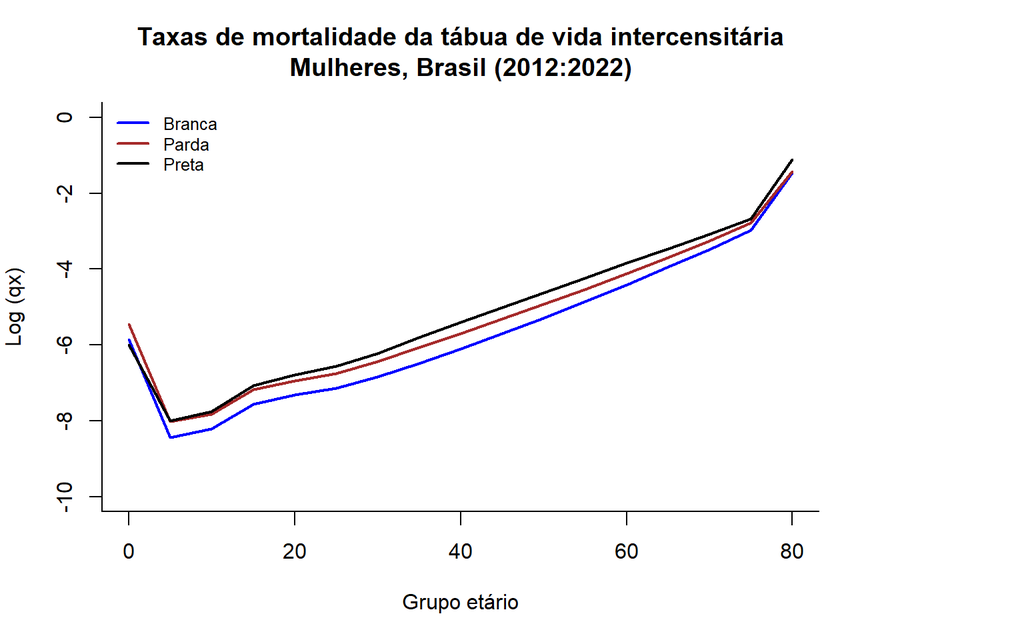

```r
idade <- DDM_MII_branca$age_x
Branca <- log(DDM_MII_branca$d_x/DDM_MII_branca$L_x)
Parda <- log(DDM_MII_parda$d_x/DDM_MII_parda$L_x)
Preta <- log(DDM_MII_preta$d_x/DDM_MII_preta$L_x)

par(mar=c(5, 4, 4, 8), xpd=TRUE)

plot(idade, Branca, type='l', col='blue', lwd=2,
     ylim=c(-10,0), ylab='Log (qx)', xlab='Grupo etário',
     main='Taxas de mortalidade da tábua de vida intercensitária\nMulheres, Brasil (2012:2022)',
     bty='l')

lines(idade, Parda, col='brown', lwd=2)
lines(idade, Preta, col='black', lwd=2)

legend("topleft",
       legend=c("Branca", "Parda", "Preta"),
       col=c("blue", "brown", "black"),
       lty=1, lwd=2, bty='n', cex=0.8)
```

### **5. Discussão**

A implementação do Método Iterativo Intercensal (MII) em ambiente R fomenta a disseminação e a reprodutibilidade desta metodologia em diversas frentes de pesquisa. Com isso, ampliam-se as possibilidades de emprego desta técnica na construção de tábuas de vida por cor/raça, especialmente em contextos onde a reclassificação racial entre censos demográficos impõe desafios analíticos à produção de indicadores que retratem, com fidedignidade, os diferenciais de mortalidade no Brasil.

A análise evidencia que a estimação da mortalidade por cor/raça no país enfrenta obstáculos que transcendem a coleta primária de dados. O cerne da discussão reside na insuficiência dos métodos tradicionais de cálculo de tábuas de vida quando aplicados a contextos de intensa migração e reclassificação racial.

A comparação entre as tábuas de vida estimadas sem correção e aquelas ajustadas pelo MII revela que o recalculo das taxas de crescimento é determinante para a plausibilidade dos resultados. Enquanto os métodos convencionais produzem expectativas de vida pouco razoáveis para mulheres pretas e pardas, em comparação com mulheres brancas, principalmente em decorrência do inflamento artificial do denominador populacional causado pela mudança de autodeclaração racial, o processo iterativo permite expurgar os efeitos da reclassificação racial intercensitária. Como resultado, obtêm-se diferenciais de mortalidade que podem refletir de forma mais precisa a realidade socioeconômica e as vulnerabilidades históricas dos grupos analisados.

### **Declaração de Uso de Inteligência Artificial**

Declaro que ferramentas de Inteligência Artificial Generativa (IA) foram utilizadas como suporte na elaboração deste documento, especificamente nas seguintes etapas:

- **Desenvolvimento de Scripts:** Auxílio na estruturação de códigos em linguagem R para otimização de funções e visualizações de dados.
- **Formatação Técnica:** Suporte na redação de sintaxe LaTeX integrada ao ambiente R Markdown.
- **Aprimoramento Textual:** Revisão gramatical, ortográfica e estilística da redação original.

Declaro, ainda, que o conteúdo foi revisado está em conformidade com a Portaria 2664/2026 do CNPq.

### **Agradecimentos**

Agradeço ao apoio recebido do Conselho Nacional de Desenvolvimento Científico e Tecnológico (Processo: 303956/2025-9).

### **Referências**

Bennett, Neil G, and Shiro Horiuchi. 1981. “Estimating the Completeness of Death Registration in a Closed Population.” *Population Index*, 207–21.

Bennett, Neil G, and Shiro Horiuchi. 1984. “Mortality Estimation from Registered Deaths in Less Developed Countries.” *Demography* 21 (2): 217–33.

Brass, William. 1975. *Methods for Estimating Fertility and Mortality from Limited and Defective Data.*

De Castro Cerqueira, Daniel Ricardo, and Rodrigo Leandro de Moura. 2014. “Vidas Perdidas e Racismo No Brasil.” *Publicatio UEPG: Ciências Sociais Aplicadas* 22 (1): 73–90.

Gonzaga, Marcos Roberto, Ana Maria Nogales Vasconcelos, and Ricardo Teixeira. 2026. *População Municipal Por Sexo, Grupos de Idade e Raça/Cor No Brasil No Período de 2010 a 2022*. Relatório Técnico não publicado.

Hill, Kenneth. 1987. “Estimating Census and Death Registration Completeness.” *Asian and Pacific Population Forum* 1: 8–24.

IBGE. 2024. *Censo Demográfico 2022: Quilombolas e Indígenas, Por Sexo e Idade, Segundo Recortes Territoriais Específicos: Resultados Do Universo*. Instituto Brasileiro de Geografia e Estatística.

Merli, M Giovanna. 1998. “Mortality in Vietnam, 1979–1989.” *Demography* 35 (3): 345–60.

Muniz, Jerônimo Oliveira. 2023. “Iterative Intercensal Single-Decrement Life Tables Using Stata.” *The Stata Journal* 23 (3): 813–34.

Preston, Samuel H. 1983. “An Integrated System for Demographic Estimation from Two Age Distributions.” *Demography* 20 (2): 213–26.

Silva Filho, Aloisio Machado da, Edna Maria de Araújo, Ionara Magalhães de Souza, et al. 2024. “Years of Potential Life Lost Due to COVID-19 According to Race/Color and Gender in Brazil Between 2020 and 2021.” *Ciência & Saúde Coletiva* 29: e04702023.

Souza, Ionara Magalhães de, Edna Maria de Araújo, and Felipe Souza Nery. 2015. “Mortalidade Masculina Segundo a Raça/Cor Da Pele Em Estados Do Nordeste e Sudeste Do Brasil, 2009-2011.” *Revista Da Associação Brasileira de Pesquisadores/as Negros/as (ABPN)* 7 (16): 154–67.